# Do females and males differ in organs scaling? A comparative analysis across vertebrates

Author

Félix P. Leiva

Published

1st May 2026

Doi

10.5281/zenodo.19953540

This supplementary file contains the *R* code for processing and analysing the raw data, and creating figures for the manuscript - *Do females and males differ in organs scaling? A comparative analysis across vertebrates*

Data subset used in this study is part of a database on organ sizes, which is available here: https://felixpleiva.github.io/organ_size_DB/. Additionally, I complemented the dataset on organ size by revisiting a recent publication by [Tsuboi et al., 2018](https://doi.org/10.1038/s41559-018-0632-1), which includes, among other information, sex- and species-specific data on organ size for numerous species of mammals, birds, and fish. Together, these approaches, allowed us to compile information for 204 vertebrate species and data on a total of 9 different organs.

```r
# Clean working environment
rm(list = ls())
```

# Documentation

## Licence

This repository is provided by the authors under the [Attribution-NonCommercial-NoDerivatives 4.0 International licence](https://creativecommons.org/licenses/by-nc-nd/4.0/)

## Citation

When using the data and/or code associated with this repository, I suggest cite them as follows:

Leiva, F. P., A. J. Hendriks. (2026). Data and code of manuscript: Do females and males differ in organ scaling? A comparative analysis across vertebrates. Zenodo. https://10.5281/zenodo.19953540.

## Contact

This script is authored by [Félix P. Leiva](https://felixpleiva.github.io/home/). For any questions related to this resource, contact Félix at the email address: felixpleiva@gmail.com.

# Data and phylogenetic tree

## Load and tidy data

```r
dat <- read_xlsx("../outputs/dat_for_analyses_full_merged.xlsx") %>%
  rename(
    sex = sex_individual,
    life_stage = life_stage_individual,
    original_category = trait_size_category,
    body_size = body_size_mean,
    organ_size = organ_size_mean,
    species = species_reported
  ) %>%
  mutate(organ_grouped = recode(organ_grouped,
                                pituitary_gland = "pituitary_glands",
                                lung = "lungs",
                                kidney = "kidneys")) %>%
  mutate(class = recode(class,
                        Actinopterygii = "Teleostei"))


# Calculate mean per species and sex. Most species were represented primarily by adults. Life stages that were not explicitly reported were assumed to correspond to adult individuals.

dat_mean <- dat %>%
  group_by(
    phylum, class, order, family, genus,
    species, sex, organ_grouped
  ) %>%
  summarise(
    body_size = mean(body_size, na.rm = TRUE),
    organ_size = mean(organ_size, na.rm = TRUE),
    .groups = "drop"
  ) %>%
  mutate(
    log10_body_size    = log10(body_size),
    log10_organ_size = log10(organ_size),
    phylo = gsub(" ", "_", species)
  )
```

Next, from the preceding code, I will extract the list of species for which I want to retrieve the phylogenetic tree and export it to my working directory.

```r
list_of_species <- dat_mean %>%
  distinct(species) %>%
  pull(species) %>%
  as.character()

writeLines(list_of_species, "../outputs/list_of_species.txt")
```

## Check data structure and transform variables if necessary

```r
glimpse(dat_mean)
```

```
Rows: 676
Columns: 13
$ phylum           <chr> "Chordata", "Chordata", "Chordata", "Chordata", "Chor…
$ class            <chr> "Aves", "Aves", "Aves", "Aves", "Aves", "Aves", "Aves…
$ order            <chr> "Anseriformes", "Anseriformes", "Anseriformes", "Anse…
$ family           <chr> "Anatidae", "Anatidae", "Anatidae", "Anatidae", "Anat…
$ genus            <chr> "Anas", "Anas", "Anas", "Anas", "Anas", "Anas", "Anas…
$ species          <chr> "Anas acuta", "Anas acuta", "Anas crecca", "Anas crec…
$ sex              <chr> "female", "male", "female", "male", "female", "female…
$ organ_grouped    <chr> "brain", "brain", "brain", "brain", "adrenal_glands",…
$ body_size        <dbl> 721, 1176, 279, 347, 2921, 1200, 2921, 2921, 2921, 29…
$ organ_size       <dbl> 4.91, 5.28, 3.18, 2.90, 0.13, 5.44, 19.50, 17.40, 3.5…
$ log10_body_size  <dbl> 2.9, 3.1, 2.4, 2.5, 3.5, 3.1, 3.5, 3.5, 3.5, 3.5, 3.5…
$ log10_organ_size <dbl> 0.691, 0.723, 0.503, 0.463, -0.886, 0.736, 1.290, 1.2…
$ phylo            <chr> "Anas_acuta", "Anas_acuta", "Anas_crecca", "Anas_crec…
```

### Variables to convert to factor

```r
columns_to_factor <- c(
  "phylum",
  "class",
  "order",
  "family",
  "genus",
  "species",
  "phylo",
  "sex",
  "organ_grouped"
)
```

### Variables to convert to numeric

```r
columns_to_numeric <- c(
  "body_size",
  "organ_size",
  "log10_organ_size",
  "log10_body_size"
)
```

### Apply transformation

```r
# Apply the conversions to the dataset.
dat_mean <- dat_mean %>%
  mutate(
    across(all_of(columns_to_factor), as.factor),
    across(all_of(columns_to_numeric), as.numeric)
  )

# Confirm that changes have been applied correctly
glimpse(dat_mean)
```

```
Rows: 676
Columns: 13
$ phylum           <fct> Chordata, Chordata, Chordata, Chordata, Chordata, Cho…
$ class            <fct> Aves, Aves, Aves, Aves, Aves, Aves, Aves, Aves, Aves,…
$ order            <fct> Anseriformes, Anseriformes, Anseriformes, Anseriforme…
$ family           <fct> Anatidae, Anatidae, Anatidae, Anatidae, Anatidae, Ana…
$ genus            <fct> Anas, Anas, Anas, Anas, Anas, Anas, Anas, Anas, Anas,…
$ species          <fct> Anas acuta, Anas acuta, Anas crecca, Anas crecca, Ana…
$ sex              <fct> female, male, female, male, female, female, female, f…
$ organ_grouped    <fct> brain, brain, brain, brain, adrenal_glands, brain, he…
$ body_size        <dbl> 721, 1176, 279, 347, 2921, 1200, 2921, 2921, 2921, 29…
$ organ_size       <dbl> 4.91, 5.28, 3.18, 2.90, 0.13, 5.44, 19.50, 17.40, 3.5…
$ log10_body_size  <dbl> 2.9, 3.1, 2.4, 2.5, 3.5, 3.1, 3.5, 3.5, 3.5, 3.5, 3.5…
$ log10_organ_size <dbl> 0.691, 0.723, 0.503, 0.463, -0.886, 0.736, 1.290, 1.2…
$ phylo            <fct> Anas_acuta, Anas_acuta, Anas_crecca, Anas_crecca, Ana…
```

Filter the dataframe to include only organs with at least five species per sex and organ. Some of them have only three species per sex. From this output, the thymus, large intestine, and small intestine are excluded.

```r
# First identify qualifying organ-sex combinations
organs_five_species <- dat_mean %>%
  count(organ_grouped, species, sex) %>%
  group_by(organ_grouped, sex) %>% # by sex and organ
  summarise(n_species = n_distinct(species), .groups = "drop") %>%
  filter(n_species >= 5) # at least 5 spp

# Then filter original data to these combinations only
dat_mean <- dat_mean %>%
  inner_join(organs_five_species %>% select(organ_grouped, sex),
             by = c("organ_grouped", "sex"))

# Lets check whcih organs were retained after this filter
dat_mean %>%
  summarise(n_species = n_distinct(species), .by = organ_grouped)
```

```
# A tibble: 10 × 2
   organ_grouped    n_species
   <fct>                <int>
 1 brain                  246
 2 adrenal_glands           7
 3 heart                   12
 4 kidneys                  8
 5 liver                   14
 6 pancreas                 6
 7 spleen                  11
 8 stomach                  8
 9 pituitary_glands         7
10 lungs                    8
```

In addition to the five-species filter, we applied a ten-species filter when the organ in question was the brain. This was done to make our analyses more comparable to those recently published by Tsuboi et al. (2018). Moreover, this approach allowed us to assess the robustness and granularity of our results within a subset of species for which more data were available. The ten-species filter encompassed a total of two families of fish, five families of birds, and three families of mammals.

```r
# Identify qualifying families (>10 unique species per family) for brain only
good_families_brain <- dat_mean %>%
  filter(organ_grouped == "brain") %>%
  group_by(family) %>%
  summarise(n_species = n_distinct(species), .groups = "drop") %>%
  filter(n_species > 10) %>%
  pull(family)

# Filter main dataset: keep ALL non-brain data + brain data for qualifying families only
dat_mean<- dat_mean %>%
  filter(organ_grouped != "brain" | family %in% good_families_brain) %>%
  droplevels() # here i drop the rows filtered out

# Species counts per organ, class, order, family
species_summary <- dat_mean %>%
  distinct(organ_grouped, class, order, family, species, .keep_all = TRUE) %>%
  count(organ_grouped, class, order, family, name = "n_species_unique") %>%
  arrange(organ_grouped, class, desc(n_species_unique))
```

One of the things I discovered recently is the [library (DT)](https://rstudio.github.io/DT/), which enables the creation of these interactive tables that allow for much more dynamic filtering. Super cool!

```r
datatable(
  species_summary,
  filter = "top",
  options = list(
    pageLength = 15,
    autoWidth = TRUE,
    dom = 'Bfrtip',
    buttons = c('copy', 'csv', 'excel')
  ),
  colnames = c("Organ", "Class", "Order", "Family", "Species count")
)
```

|  | Organ | Class | Order | Family | Species count |
| --- | --- | --- | --- | --- | --- |
| 1 | adrenal_glands | Aves | Anseriformes | Anatidae | 1 |
| 2 | adrenal_glands | Aves | Galliformes | Phasianidae | 1 |
| 3 | adrenal_glands | Mammalia | Primates | Cercopithecidae | 2 |
| 4 | adrenal_glands | Mammalia | Rodentia | Muridae | 2 |
| 5 | adrenal_glands | Mammalia | Primates | Cebidae | 1 |
| 6 | brain | Aves | Psittaciformes | Psittacidae | 44 |
| 7 | brain | Aves | Passeriformes | Fringillidae | 26 |
| 8 | brain | Aves | Galliformes | Phasianidae | 21 |
| 9 | brain | Aves | Passeriformes | Estrildidae | 19 |
| 10 | brain | Aves | Anseriformes | Anatidae | 15 |

[output cut: 55 more lines]

## Load and prune phylogenetic tree

```r
tree <- read.tree("../outputs/phylogenetic_tree.nwk")

# Number of tips (species)
length(tree$tip.label)
```

```
[1] 277
```

Our next step is to prune the tree to retain only those species for which organ size measurements exist for both males and females. This pruning is important because our phylogenetic informed analyses require the calculation of a variance-covariance matrix based on the shared evolutionary history of the species.

```r
# Check for database/tree species mismatches
setdiff(tree$tip.label, dat_mean$phylo)      # Tree species absent in database
```

```
 [1] "Pseudosimochromis_babaulti"
 [2] "Oostethus_brachyurus"
 [3] "Dunckerocampus_dactyliophorus"
 [4] "Madoqua_kirkii"
 [5] "Philantomba_monticola"
 [6] "Aotus_trivirgatus"
 [7] "Cebuella_pygmaea"
 [8] "Callithrix_penicillata"
 [9] "Callimico_goeldii"
[10] "Leontopithecus_chrysomelas"
[11] "Leontopithecus_rosalia"
[12] "Leontocebus_fuscicollis_illigeri"
[13] "Saguinus_mystax"
[14] "Saguinus_labiatus_labiatus"
[15] "Saguinus_leucopus"
```

[output cut: 58 more lines]

```r
setdiff(dat_mean$phylo, tree$tip.label)      # Database species absent in tree
```

```
 [1] "Nyroca_fuligula"              "Ammoperdix_griseogularis"
 [3] "Bonasa_bonasia"               "Gallus_lafayetii"
 [5] "Lagopus_mutus"                "Erythrura_gouldiae"
 [7] "Lonchura_grandis"             "Lonchura_molucca"
 [9] "Lonchura_pallida"             "Lonchura_quinticolor"
[11] "Lonchura_spectabilis"         "Lonchura_tristissima"
[13] "Mandingoa_nitidula"           "Neochmia_ruficauda"
[15] "Pyrenestes_ostrinus"          "Uraeginthus_ianthinogaster"
[17] "Carduelis_ambigua"            "Carduelis_cannabina"
[19] "Carduelis_chloris"            "Carduelis_cucullata"
[21] "Carduelis_flammea"            "Carduelis_spinoides"
[23] "Carduelis_spinus"             "Serinus_burtoni"
[25] "Serinus_dorsostriatus"        "Serinus_mozambicus"
[27] "Cacatua_leadbeateri"          "Calyptorhynchus_funereus"
[29] "Orthopsittaca_manilata"       "Polytelis_swainsonii"
[31] "Psephotus_varius"             "Cephalophus_monticola"
[33] "Eudorcas_thomsoni"            "Madoqua_kirki"
[35] "Saimiri_sciureus"             "Chlorocebus_aethiops_sabaeus"
[37] "Simochromis_babaulti"         "Doryichthys_martensi"
[39] "Doryrhamphus_dactyliophorus"  "Microphis_brachyurus"
[41] "Trachyhampus_serratus"
```

```r
# Exclude mismatched species for consistency
tree <- keep.tip(tree, intersect(tree$tip.label, dat_mean$phylo))
dat_mean <- dat_mean[dat_mean$phylo %in% tree$tip.label, ]

# Re-check for mismatches after pruning
setdiff(tree$tip.label, dat_mean$phylo)
```

```
character(0)
```

```r
setdiff(dat_mean$phylo, tree$tip.label)
```

```
character(0)
```

```r
# Is ultrametric?
is.ultrametric(tree)
```

```
[1] TRUE
```

```r
# how many species?
length(tree$tip.label)
```

```
[1] 204
```

```r
# Compute phylogenetic covariance matrix (Brownian motion)
A <- vcv.phylo(tree, corr = TRUE)
```

How many species have phylogenetic information available across all taxonomic classes for the brain?

```r
dat_mean %>%
  count(organ_grouped, species, class) %>%
  group_by(organ_grouped) %>%
  filter(organ_grouped == "brain") %>%
  summarise(
    n_species = n_distinct(species),
    .groups = 'drop'
  ) %>%
  arrange(desc(n_species))
```

```
# A tibble: 1 × 2
  organ_grouped n_species
  <fct>             <int>
1 brain               189
```

```r
dat_mean %>%
  count(organ_grouped, species) %>%
  group_by(organ_grouped) %>%
  count(organ_grouped, name = "n_species") %>%
  arrange(desc(n_species))
```

```
# A tibble: 10 × 2
# Groups:   organ_grouped [10]
   organ_grouped    n_species
   <fct>                <int>
 1 brain                  189
 2 liver                   12
 3 heart                   10
 4 spleen                   9
 5 stomach                  8
 6 kidneys                  6
 7 lungs                    6
 8 adrenal_glands           5
 9 pituitary_glands         5
10 pancreas                 4
```

Exclude pancreas from the analysis (only four species)

```r
dat_mean <- dat_mean %>%
  filter(organ_grouped != "pancreas")

# Confirm pancreas is gone
unique(dat_mean$organ_grouped)
```

```
[1] brain            adrenal_glands   heart            kidneys
[5] liver            spleen           stomach          pituitary_glands
[9] lungs
10 Levels: adrenal_glands brain heart kidneys liver lungs ... stomach
```

and now re-run the previous lines para merge the tree and data

```r
# Check for database/tree species mismatches
setdiff(tree$tip.label, dat_mean$phylo)      # Tree species absent in database
```

```
character(0)
```

```r
setdiff(dat_mean$phylo, tree$tip.label)      # Database species absent in tree
```

```
character(0)
```

```r
# Exclude mismatched species for consistency
tree <- keep.tip(tree, intersect(tree$tip.label, dat_mean$phylo))
dat_mean <- dat_mean[dat_mean$phylo %in% tree$tip.label, ]

# Re-check for mismatches after pruning
setdiff(tree$tip.label, dat_mean$phylo)
```

```
character(0)
```

```r
setdiff(dat_mean$phylo, tree$tip.label)
```

```
character(0)
```

```r
# Is ultrametric?q
is.ultrametric(tree)
```

```
[1] TRUE
```

```r
# how many species?
length(tree$tip.label)
```

```
[1] 204
```

```r
# Compute phylogenetic covariance matrix (Brownian motion)
A <- vcv.phylo(tree, corr = TRUE)
```

Lets count species again by organ

```r
dat_mean %>%
  count(organ_grouped, species) %>%
  group_by(organ_grouped) %>%
  count(organ_grouped, name = "n_species") %>%
  arrange(desc(n_species))
```

```
# A tibble: 9 × 2
# Groups:   organ_grouped [9]
  organ_grouped    n_species
  <fct>                <int>
1 brain                  189
2 liver                   12
3 heart                   10
4 spleen                   9
5 stomach                  8
6 kidneys                  6
7 lungs                    6
8 adrenal_glands           5
9 pituitary_glands         5
```

and taxonomic Class

```r
dat_mean %>%
  count(class, species) %>%
  group_by(class) %>%
  count(class, name = "n_species") %>%
  arrange(desc(n_species))
```

```
# A tibble: 4 × 2
# Groups:   class [4]
  class     n_species
  <fct>         <int>
1 Aves             98
2 Teleostei        70
3 Mammalia         35
4 Reptilia          1
```

# Important note!

Our analyses for most organs are based on a relatively small number of observations (i.e., species). This may limit the interpretability of our models. Cross-validation (via the loo_compare function) was implemented in some cases following the recommendations in the [cross-validation FAQ](https://mc-stan.org/loo/articles/online-only/faq.html#high_khat), particularly regarding influential observations. In the preceding link Aki Vehtari states: *Pareto-k is also useful as a measure of influence of an observation. Highly influential observations have high k^ values. Very high k values often indicate model misspecification, outliers or mistakes in data processing*. For this reason, I decided to include additional species by searching for complementary datasets. We incorporated the dataset from Tsuboi et al., which, to our knowledge, represents the most extensive available compilation of vertebrate brain size. I filtered the entries where sex was reported for same species.

# Figure 1

The figure below illustrates the expected response scenarios for the scaling relationships between organ size and body mass in males and females.

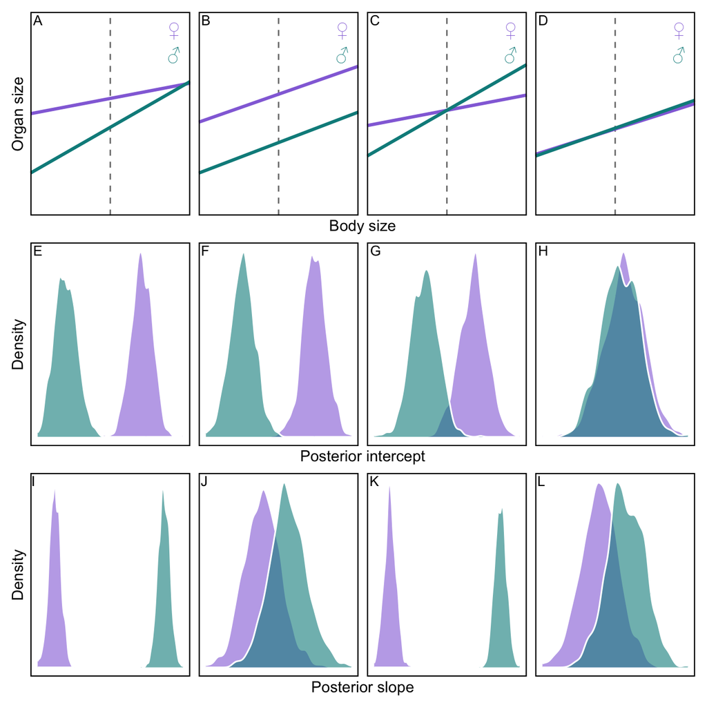

```r
# Set colors by sex
cols <- c(male = "#008B8B", female = "#9370DB")

# Implemented  on a previous script: https://felixpleiva.github.io/correlated_evolution_moths/

sex_symbols <- tibble(
  sex    = c("female", "male"),
  symbol = c("\u2640", "\u2642"),
  body_size  = c(0.9, 0.9),
  organ_size = c(1.10, 0.95)
)

# Define theme
base_theme <- theme_bw(base_size = 12) +
  theme(
    panel.grid.major = element_blank(),
    panel.grid.minor = element_blank(),
    legend.position  = "none",
    axis.text.x      = element_blank(),
    axis.text.y      = element_blank(),
    axis.ticks.x     = element_blank(),
    axis.ticks.y     = element_blank(),
    axis.title       = element_text(size = 11),
    panel.border     = element_rect(colour = "black", fill = NA, size = 0.8),
    plot.margin      = margin(3, 3, 3, 3)
  )

# helper conceptual tribble to identify data structure
lines_df <- tribble(
  ~ panel, ~ sex,      ~ intercept, ~ slope,
  "a",    "male",        0.25,      0.18*3,
  "a",    "female",      0.60,      0.06*3,
  "b",    "male",        0.25,      0.12*3,
  "b",    "female",      0.55,      0.11*3,
  "c",    "male",        0.35,      0.18*3,
  "c",    "female",      0.38,      0.06*3,
  "d",    "male",        0.35,      0.11*3,
  "d",    "female",      0.36,      0.10*3
)

# position of vertical line
x_mid <- 0.5

# Adjust only panel c so that male and female intersect at x_mid...I am doing this for illustrative purposes only.
lines_df2 <- lines_df %>%
  group_by(panel) %>%
  mutate(
    intercept = case_when(
      panel != "c" ~ intercept,
      panel == "c" & sex == "male" ~ intercept,
      panel == "c" & sex == "female" ~ (
        intercept[sex == "male"] +
          slope[sex == "male"] * x_mid -
          slope[sex == "female"] * x_mid
      )
    )
  ) %>%
  ungroup()

x_seq <- seq(0, 1, length.out = 50)

plot_df <- lines_df2 %>%
  tidyr::expand_grid(body_size = x_seq) %>%
  mutate(organ_size = intercept + slope * body_size)

# Function to add letters in the panel
add_tag_inside <- function(p, tag) {
  p +
    annotate(
      "text",
      x = -Inf, y = Inf,
      label = tag,
      hjust = -0.3, vjust = 1.3,
      size = 3.5
    )
}

# Function to make four scenarios of scaling for females and males
make_panel <- function(p, x_lab, y_lab = NULL) {
  ggplot(filter(plot_df, panel == p),
         aes(x = body_size, y = organ_size,
             colour = sex, group = sex)) +
    geom_vline(xintercept = x_mid,
               linetype = "dashed",
               colour   = "grey50",
               linewidth = 0.5) +
    geom_line(linewidth = 1.1) +
    geom_text(
      data = sex_symbols,
      aes(x = body_size, y = organ_size,
          label = symbol, colour = sex),
      inherit.aes = FALSE,
      size = 4.5,
      fontface = "bold"
    ) +
    scale_colour_manual(values = cols, name = NULL) +
    labs(x = x_lab, y = y_lab) +
    coord_cartesian(xlim = c(0, 1), ylim = c(0, 1.2), expand = FALSE) +
    base_theme
}
# Make plots
p1 <- make_panel("a", x_lab = "Body size", y_lab = "Organ size") %>% add_tag_inside("A")
p2 <- make_panel("b", x_lab = "Body size", y_lab = NULL)         %>% add_tag_inside("B")
p3 <- make_panel("c", x_lab = "Body size", y_lab = NULL)         %>% add_tag_inside("C")
p4 <- make_panel("d", x_lab = "Body size", y_lab = NULL)         %>% add_tag_inside("D")

# Simulations of posterior distributions (again 4 illustrative only)
set.seed(6955)

post_df <- lines_df2 %>%
  group_by(panel, sex) %>%
  do({
    tibble(
      draw = 1:1000,
      intercept = rnorm(1000, .$intercept, 0.05),
      slope     = rnorm(1000, .$slope,     0.02)
    )
  }) %>%
  ungroup()

post_long <- post_df %>%
  pivot_longer(c(intercept, slope),
               names_to = "parameter",
               values_to = "value")

make_posterior_panel <- function(panel_id, param, x_lab, y_lab = NULL) {
  post_long %>%
    filter(panel == panel_id, parameter == param) %>%
    ggplot(aes(x = value, fill = sex, colour = sex)) +
    geom_density(alpha = 0.6, adjust = 0.8, color = "white") +
    scale_fill_manual(values = cols, name = NULL) +
    scale_colour_manual(values = cols, guide = "none") +
    labs(x = x_lab, y = y_lab) +
    base_theme
}

# Posterior intercepts (e–h)
p5  <- make_posterior_panel("a", "intercept", "Posterior intercept", y_lab = "Density") %>% add_tag_inside("E")
p6  <- make_posterior_panel("b", "intercept", "Posterior intercept", y_lab = NULL)      %>% add_tag_inside("F")
p7  <- make_posterior_panel("c", "intercept", "Posterior intercept", y_lab = NULL)      %>% add_tag_inside("G")
p8  <- make_posterior_panel("d", "intercept", "Posterior intercept", y_lab = NULL)      %>% add_tag_inside("H")

# Posterior slopes (i–l)
p9  <- make_posterior_panel("a", "slope", "Posterior slope", y_lab = "Density") %>% add_tag_inside("I")
p10 <- make_posterior_panel("b", "slope", "Posterior slope", y_lab = NULL)      %>% add_tag_inside("J")
p11 <- make_posterior_panel("c", "slope", "Posterior slope", y_lab = NULL)      %>% add_tag_inside("K")
p12 <- make_posterior_panel("d", "slope", "Posterior slope", y_lab = NULL)      %>% add_tag_inside("L")

# Combine plots
Figure_1 <- wrap_plots(
  p1, p2, p3, p4,
  p5, p6, p7, p8,
  p9, p10, p11, p12,
  nrow = 3, ncol = 4, byrow = TRUE
) +
  plot_layout(
    axis_titles = "collect_x"
  )

Figure_1
```

```r
# Export figure
ggsave("../outputs/Figure_1.png", Figure_1, width = 7, height = 6, dpi = 1200)
```

# Figure 2

Now the tree match the species in the dataframe, we will create a figure of the phylogenetic tree containing the 204 species for which we have organ size data for both males and females. We will add a plot indicating whether each organ was measured (dark grey) or not (grey).

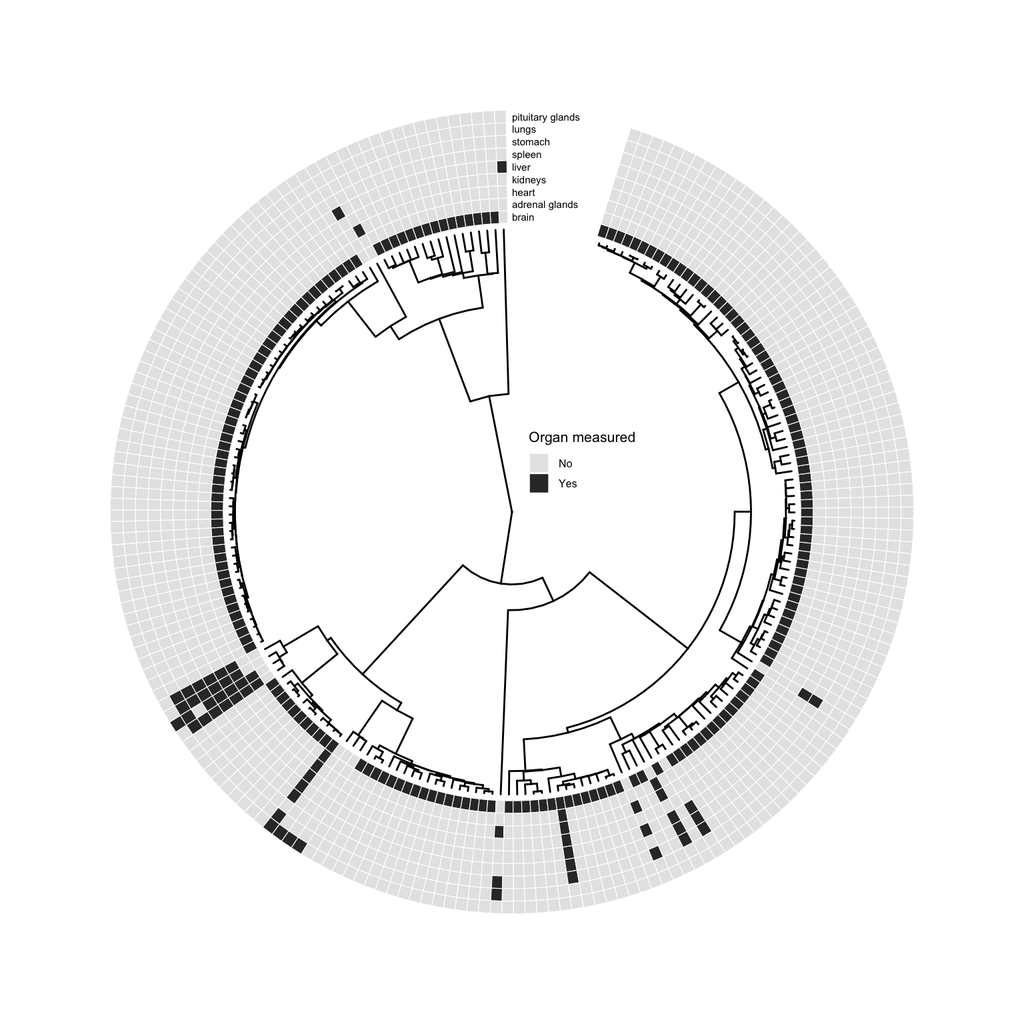

```r
# Prepare data to merge with tree
dat_mean$organ_grouped <- gsub("_", " ", dat_mean$organ_grouped)

# I make a yes/no binary variable to indicate in the tree which organs were measured for a given species
summary_data <- dat_mean %>%
  count(phylo, organ_grouped) %>%
  mutate(presence = if_else(n > 0, "Yes", "No")) %>%
  select(-n) %>%
  pivot_wider(
    names_from = organ_grouped,
    values_from = presence,
    values_fill = list(presence = "No")
  )

summary_data <- summary_data[summary_data$phylo %in% tree$tip.label, ]

datF_organs <- summary_data %>%
  column_to_rownames("phylo") %>%
  as.matrix()

# force matc between data and tree
datF_organs <- datF_organs[tree$tip.label, , drop = FALSE]

# Create phylogeny tree
circ <- ggtree(tree, layout = "fan", open.angle = 18)
circ <- rotate_tree(circ, 90)

Figure_2 <- gheatmap(
  circ,
  datF_organs,
  width = 0.4,
  offset = 0,
  colnames_offset_x = 0,
  colnames_offset_y = 0,
  font.size = 2,
  hjust = 0
) +
  scale_fill_manual(values = c("grey90", "grey20"), name = "Organ measured")  +
  theme(
    legend.position = c(0.57, 0.55),
    legend.background = element_rect(fill = "transparent", colour = NA),
    legend.box.background = element_rect(fill = "transparent", colour = NA),
    legend.title = element_text(size = 8),
    legend.text = element_text(size = 6),
    legend.key.size = unit(0.8, "cm"),
    legend.key.height = unit(0.4, "cm"),
    legend.key.width = unit(0.4, "cm")
  )

Figure_2
```

```r
# Export figure
ggsave('../outputs/Figure_2.pdf', Figure_2, width = 7, height = 7)
```

# Analysis by organ

## Liver

### Filter data and prune tree

```r
# Filter organ of interest
dat_organ <- dat_mean %>%
  group_by(organ_grouped, sex) %>%
  ungroup() %>%
  filter(organ_grouped == "liver")

# Check for database/tree species mismatches
setdiff(tree$tip.label, dat_organ$phylo)      # Tree species absent in database
```

```
  [1] "Petrochromis_famula"             "Lobochilotes_labiatus"
  [3] "Simochromis_diagramma"           "Petrochromis_orthognathus"
  [5] "Ctenochromis_horei"              "Limnotilapia_dardennii"
  [7] "Gnathochromis_pfefferi"          "Tropheus_moorii"
  [9] "Tropheus_brichardi"              "Haplotaxodon_microlepis"
 [11] "Perissodus_microlepis"           "Benthochromis_tricoti"
 [13] "Cyprichromis_leptosoma"          "Greenwoodochromis_christyi"
 [15] "Limnochromis_staneri"            "Gnathochromis_permaxillaris"
 [17] "Baileychromis_centropomoides"    "Triglachromis_otostigma"
 [19] "Cyphotilapia_frontosa"           "Ophthalmotilapia_ventralis"
 [21] "Cyathopharynx_furcifer"          "Ophthalmotilapia_nasuta"
 [23] "Ophthalmotilapia_boops"          "Aulonocranus_dewindti"
 [25] "Ectodus_descampsii"              "Callochromis_melanostigma"
 [27] "Xenotilapia_melanogenys"         "Xenotilapia_flavipinnis"
 [29] "Eretmodus_cyanostictus"          "Tanganicodus_irsacae"
```

[output cut: 81 more lines]

```r
setdiff(dat_organ$phylo, tree$tip.label)      # Database species absent in tree
```

```
character(0)
```

```r
# Exclude mismatched species for consistency
tree_organ <- keep.tip(tree, intersect(tree$tip.label, dat_organ$phylo))
dat_organ <- dat_organ[dat_organ$phylo %in% tree_organ$tip.label, ]

# Re-check for mismatches after pruning
setdiff(tree_organ$tip.label, dat_organ$phylo)
```

```
character(0)
```

```r
setdiff(dat_organ$phylo, tree_organ$tip.label)
```

```
character(0)
```

```r
# Is ultrametric?
is.ultrametric(tree_organ)
```

```
[1] TRUE
```

```r
# how many species?
length(tree_organ$tip.label)
```

```
[1] 12
```

```r
# Compute phylogenetic covariance matrix
A_organ <- ape::vcv.phylo(tree_organ, corr = TRUE)
```

### Model simple

```r
model_simple_liver <- brm(
  log10_organ_size ~
    1 +
    log10_body_size +
    (1 + log10_body_size | sex),
  data = dat_organ,
  family = gaussian(),
    prior = c(
    prior(normal(0.75, 0.5), class = "b", coef = "log10_body_size"),
    prior(normal(0, 2), class = "Intercept"),
    prior(student_t(3, 0, 0.5), class = "sd"),
    prior(student_t(3, 0, 1),   class = "sigma")
  ),
  seed = 6955,
  sample_prior = TRUE,
  chains = 4,
  cores = 4,
  threads = threading(2),
  iter = 4000,
  warmup = 2000,
  control = list(max_treedepth = 15,
                 adapt_delta = 0.99),
  save_pars = save_pars(all = TRUE),
  silent = TRUE, refresh = 0
)
```

```
Running MCMC with 4 parallel chains, with 2 thread(s) per chain...

Chain 2 finished in 2.7 seconds.
Chain 4 finished in 3.4 seconds.
Chain 3 finished in 3.7 seconds.
Chain 1 finished in 4.3 seconds.

All 4 chains finished successfully.
Mean chain execution time: 3.5 seconds.
Total execution time: 4.4 seconds.
```

**Model check**

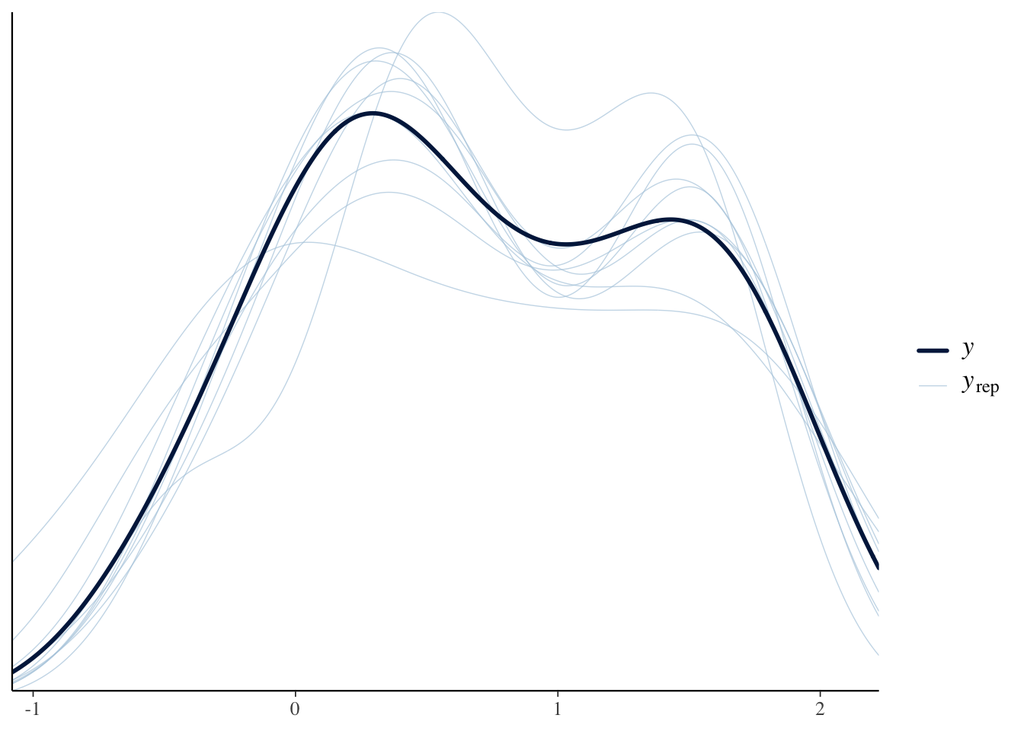

```r
pp_check(model_simple_liver)
```

**Model summary**

```r
summary(model_simple_liver)
```

```
 Family: gaussian
  Links: mu = identity
Formula: log10_organ_size ~ 1 + log10_body_size + (1 + log10_body_size | sex)
   Data: dat_organ (Number of observations: 24)
  Draws: 4 chains, each with iter = 4000; warmup = 2000; thin = 1;
         total post-warmup draws = 8000

Multilevel Hyperparameters:
~sex (Number of levels: 2)
                               Estimate Est.Error l-95% CI u-95% CI Rhat
sd(Intercept)                      0.30      0.31     0.01     1.12 1.00
sd(log10_body_size)                0.18      0.22     0.00     0.81 1.00
cor(Intercept,log10_body_size)    -0.08      0.59    -0.97     0.95 1.00
                               Bulk_ESS Tail_ESS
sd(Intercept)                      2690     2972
sd(log10_body_size)                1903     3263
cor(Intercept,log10_body_size)     4124     4348

Regression Coefficients:
                Estimate Est.Error l-95% CI u-95% CI Rhat Bulk_ESS Tail_ESS
Intercept          -1.34      0.31    -1.98    -0.75 1.00     2946     2317
log10_body_size     0.85      0.15     0.48     1.14 1.00     1706     1586

Further Distributional Parameters:
      Estimate Est.Error l-95% CI u-95% CI Rhat Bulk_ESS Tail_ESS
sigma     0.18      0.03     0.13     0.26 1.00     5259     4010

Draws were sampled using sample(hmc). For each parameter, Bulk_ESS
and Tail_ESS are effective sample size measures, and Rhat is the potential
scale reduction factor on split chains (at convergence, Rhat = 1).
```

**Coeficients by sex**

```r
# Extract combined coefficients (fixed + random)
coef(model_simple_liver)$sex %>%
{tibble(
  sex = dimnames(.)[[1]],
  intercept    = .[, "Estimate", "Intercept"],
  intercept_low  = .[, "Q2.5", "Intercept"],
  intercept_high = .[, "Q97.5", "Intercept"]
)} %>%
bind_cols(
  tibble(
    sex = dimnames(coef(model_simple_liver)$sex)[[1]],
    slope = coef(model_simple_liver)$sex[, "Estimate", "log10_body_size"]
  ) %>% select(slope),
  tibble(
    sex = dimnames(coef(model_simple_liver)$sex)[[1]],
    slope_low  = coef(model_simple_liver)$sex[, "Q2.5", "log10_body_size"],
    slope_high = coef(model_simple_liver)$sex[, "Q97.5", "log10_body_size"]
  ) %>% select(slope_low, slope_high)
)
```

```
# A tibble: 2 × 7
  sex    intercept intercept_low intercept_high slope slope_low slope_high
  <chr>      <dbl>         <dbl>          <dbl> <dbl>     <dbl>      <dbl>
1 female     -1.29         -1.56          -1.01 0.868     0.756      0.976
2 male       -1.36         -1.63          -1.10 0.876     0.772      0.986
```

### Model with phylogeny

```r
model_phylo_liver <- brm(
  log10_organ_size ~
    1 +
    log10_body_size +
    (1 + log10_body_size | sex) +
    (1 | gr(phylo, cov = A_organ)),
  data = dat_organ,
  data2 = list(A_organ = A_organ),
  family = gaussian(),
    prior = c(
    prior(normal(0.75, 0.5), class = "b", coef = "log10_body_size"),
    prior(normal(0, 2), class = "Intercept"),
    prior(student_t(3, 0, 0.5), class = "sd"),
    prior(student_t(3, 0, 1),   class = "sigma")
  ),
  seed = 6955,
  sample_prior = TRUE,
  chains = 4,
  cores = 4,
  threads = threading(2),
  iter = 4000,
  warmup = 2000,
  control = list(max_treedepth = 15,
                 adapt_delta = 0.99),
  save_pars = save_pars(all = TRUE),
  silent = TRUE, refresh = 0
)
```

```
Running MCMC with 4 parallel chains, with 2 thread(s) per chain...

Chain 1 finished in 13.5 seconds.
Chain 3 finished in 13.8 seconds.
Chain 4 finished in 14.5 seconds.
Chain 2 finished in 15.1 seconds.

All 4 chains finished successfully.
Mean chain execution time: 14.2 seconds.
Total execution time: 15.2 seconds.
```

**Model check**

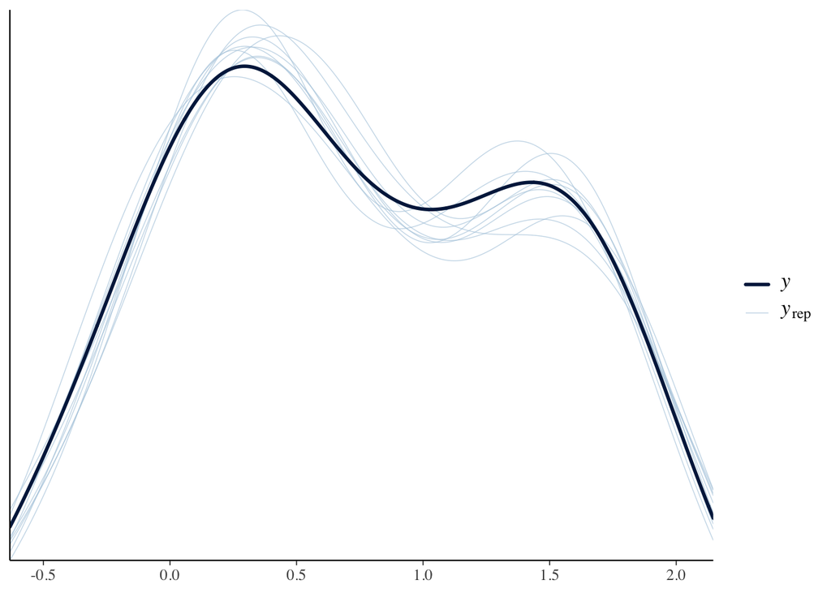

```r
pp_check(model_phylo_liver)
```

**Model summary**

```r
summary(model_phylo_liver)
```

```
 Family: gaussian
  Links: mu = identity
Formula: log10_organ_size ~ 1 + log10_body_size + (1 + log10_body_size | sex) + (1 | gr(phylo, cov = A_organ))
   Data: dat_organ (Number of observations: 24)
  Draws: 4 chains, each with iter = 4000; warmup = 2000; thin = 1;
         total post-warmup draws = 8000

Multilevel Hyperparameters:
~phylo (Number of levels: 12)
              Estimate Est.Error l-95% CI u-95% CI Rhat Bulk_ESS Tail_ESS
sd(Intercept)     0.18      0.06     0.10     0.32 1.00     2763     4184

~sex (Number of levels: 2)
                               Estimate Est.Error l-95% CI u-95% CI Rhat
sd(Intercept)                      0.25      0.28     0.01     0.99 1.00
sd(log10_body_size)                0.16      0.21     0.00     0.76 1.00
cor(Intercept,log10_body_size)    -0.04      0.62    -0.97     0.96 1.00
                               Bulk_ESS Tail_ESS
sd(Intercept)                      3416     3875
sd(log10_body_size)                2082     3720
cor(Intercept,log10_body_size)     5444     5035

Regression Coefficients:
                Estimate Est.Error l-95% CI u-95% CI Rhat Bulk_ESS Tail_ESS
Intercept          -1.48      0.27    -2.04    -0.96 1.00     3236     3945
log10_body_size     0.88      0.14     0.51     1.13 1.00     1986     1545

Further Distributional Parameters:
      Estimate Est.Error l-95% CI u-95% CI Rhat Bulk_ESS Tail_ESS
sigma     0.07      0.01     0.04     0.10 1.00     3602     5314

Draws were sampled using sample(hmc). For each parameter, Bulk_ESS
and Tail_ESS are effective sample size measures, and Rhat is the potential
scale reduction factor on split chains (at convergence, Rhat = 1).
```

**Phylogenetic signal**

```r
hyp <- paste(
  "sd_phylo__Intercept^2 /",
  "(sd_phylo__Intercept^2 + sd_sex__Intercept^2 + sigma^2) = 0"
)
(hyp <- hypothesis(model_phylo_liver, hyp, class = NULL))
```

```
Hypothesis Tests for class :
                Hypothesis Estimate Est.Error CI.Lower CI.Upper Evid.Ratio
1 (sd_phylo__Interc... = 0     0.48       0.3     0.02     0.93       0.19
  Post.Prob Star
1      0.16    *
---
'CI': 90%-CI for one-sided and 95%-CI for two-sided hypotheses.
'*': For one-sided hypotheses, the posterior probability exceeds 95%;
for two-sided hypotheses, the value tested against lies outside the 95%-CI.
Posterior probabilities of point hypotheses assume equal prior probabilities.
```

```r
lambda_liver <- hyp$hypothesis$Estimate
```

**Coeficients by sex**

```r
# Extract combined coefficients (fixed + random)
coef(model_phylo_liver)$sex %>%
{tibble(
  sex = dimnames(.)[[1]],
  intercept    = .[, "Estimate", "Intercept"],
  intercept_low  = .[, "Q2.5", "Intercept"],
  intercept_high = .[, "Q97.5", "Intercept"]
)} %>%
bind_cols(
  tibble(
    sex = dimnames(coef(model_phylo_liver)$sex)[[1]],
    slope = coef(model_phylo_liver)$sex[, "Estimate", "log10_body_size"]
  ) %>% select(slope),
  tibble(
    sex = dimnames(coef(model_phylo_liver)$sex)[[1]],
    slope_low  = coef(model_phylo_liver)$sex[, "Q2.5", "log10_body_size"],
    slope_high = coef(model_phylo_liver)$sex[, "Q97.5", "log10_body_size"]
  ) %>% select(slope_low, slope_high)
)
```

```
# A tibble: 2 × 7
  sex    intercept intercept_low intercept_high slope slope_low slope_high
  <chr>      <dbl>         <dbl>          <dbl> <dbl>     <dbl>      <dbl>
1 female     -1.45         -1.73          -1.19 0.896     0.827      0.969
2 male       -1.50         -1.78          -1.24 0.893     0.825      0.966
```

### Model comparison

```r
loo_simple <- loo(model_simple_liver)
loo_phylo <- loo(model_phylo_liver)
loo_compare(loo_simple, loo_phylo)
```

```
                   elpd_diff se_diff
model_phylo_liver    0.0       0.0
model_simple_liver -19.2       3.8
```

## Heart

### Filter data and prune tree

```r
# Filter organ of interest
dat_organ <- dat_mean %>%
  group_by(organ_grouped, sex) %>%
  ungroup() %>%
  filter(organ_grouped == "heart")

# Check for database/tree species mismatches
setdiff(tree$tip.label, dat_organ$phylo)      # Tree species absent in database
```

```
  [1] "Petrochromis_famula"             "Lobochilotes_labiatus"
  [3] "Simochromis_diagramma"           "Petrochromis_orthognathus"
  [5] "Ctenochromis_horei"              "Limnotilapia_dardennii"
  [7] "Gnathochromis_pfefferi"          "Tropheus_moorii"
  [9] "Tropheus_brichardi"              "Haplotaxodon_microlepis"
 [11] "Perissodus_microlepis"           "Benthochromis_tricoti"
 [13] "Cyprichromis_leptosoma"          "Greenwoodochromis_christyi"
 [15] "Limnochromis_staneri"            "Gnathochromis_permaxillaris"
 [17] "Baileychromis_centropomoides"    "Triglachromis_otostigma"
 [19] "Cyphotilapia_frontosa"           "Ophthalmotilapia_ventralis"
 [21] "Cyathopharynx_furcifer"          "Ophthalmotilapia_nasuta"
 [23] "Ophthalmotilapia_boops"          "Aulonocranus_dewindti"
 [25] "Ectodus_descampsii"              "Callochromis_melanostigma"
 [27] "Xenotilapia_melanogenys"         "Xenotilapia_flavipinnis"
 [29] "Eretmodus_cyanostictus"          "Tanganicodus_irsacae"
```

[output cut: 82 more lines]

```r
setdiff(dat_organ$phylo, tree$tip.label)      # Database species absent in tree
```

```
character(0)
```

```r
# Exclude mismatched species for consistency
tree_organ <- keep.tip(tree, intersect(tree$tip.label, dat_organ$phylo))
dat_organ <- dat_organ[dat_organ$phylo %in% tree_organ$tip.label, ]

# Re-check for mismatches after pruning
setdiff(tree_organ$tip.label, dat_organ$phylo)
```

```
character(0)
```

```r
setdiff(dat_organ$phylo, tree_organ$tip.label)
```

```
character(0)
```

```r
# Is ultrametric?
is.ultrametric(tree_organ)
```

```
[1] TRUE
```

```r
# how many species?
length(tree_organ$tip.label)
```

```
[1] 10
```

```r
# Compute phylogenetic covariance matrix
A_organ <- ape::vcv.phylo(tree_organ, corr = TRUE)
```

### Model simple

```r
model_simple_heart <- brm(
  log10_organ_size ~
    1 +
    log10_body_size +
    (1 + log10_body_size | sex),
  data = dat_organ,
  family = gaussian(),
    prior = c(
    prior(normal(0.75, 0.5), class = "b", coef = "log10_body_size"),
    prior(normal(0, 2), class = "Intercept"),
    prior(student_t(3, 0, 0.5), class = "sd"),
    prior(student_t(3, 0, 1),   class = "sigma")
  ),
  seed = 6955,
  sample_prior = TRUE,
  chains = 4,
  cores = 4,
  threads = threading(2),
  iter = 4000,
  warmup = 2000,
  control = list(max_treedepth = 15,
                 adapt_delta = 0.99),
  save_pars = save_pars(all = TRUE),
  silent = TRUE, refresh = 0
)
```

```
Running MCMC with 4 parallel chains, with 2 thread(s) per chain...

Chain 2 finished in 2.0 seconds.
Chain 4 finished in 2.6 seconds.
Chain 1 finished in 3.2 seconds.
Chain 3 finished in 3.1 seconds.

All 4 chains finished successfully.
Mean chain execution time: 2.7 seconds.
Total execution time: 3.3 seconds.
```

**Model check**

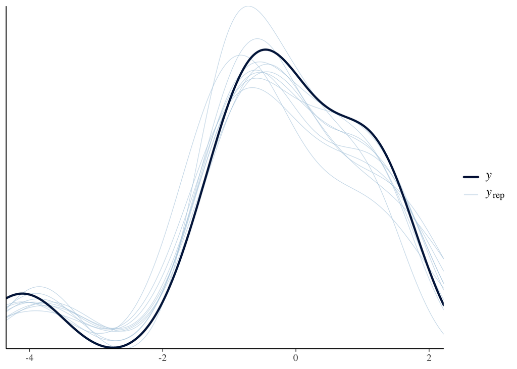

```r
pp_check(model_simple_heart)
```

**Model summary**

```r
summary(model_simple_heart)
```

```
 Family: gaussian
  Links: mu = identity
Formula: log10_organ_size ~ 1 + log10_body_size + (1 + log10_body_size | sex)
   Data: dat_organ (Number of observations: 20)
  Draws: 4 chains, each with iter = 4000; warmup = 2000; thin = 1;
         total post-warmup draws = 8000

Multilevel Hyperparameters:
~sex (Number of levels: 2)
                               Estimate Est.Error l-95% CI u-95% CI Rhat
sd(Intercept)                      0.27      0.30     0.01     1.04 1.00
sd(log10_body_size)                0.19      0.22     0.00     0.80 1.00
cor(Intercept,log10_body_size)    -0.07      0.61    -0.97     0.95 1.00
                               Bulk_ESS Tail_ESS
sd(Intercept)                      3635     3605
sd(log10_body_size)                2149     3479
cor(Intercept,log10_body_size)     4205     4565

Regression Coefficients:
                Estimate Est.Error l-95% CI u-95% CI Rhat Bulk_ESS Tail_ESS
Intercept          -2.92      0.29    -3.49    -2.35 1.00     3737     3845
log10_body_size     1.20      0.16     0.79     1.49 1.00     2413     2315

Further Distributional Parameters:
      Estimate Est.Error l-95% CI u-95% CI Rhat Bulk_ESS Tail_ESS
sigma     0.25      0.05     0.18     0.36 1.00     5488     3595

Draws were sampled using sample(hmc). For each parameter, Bulk_ESS
and Tail_ESS are effective sample size measures, and Rhat is the potential
scale reduction factor on split chains (at convergence, Rhat = 1).
```

**Coefficients by sex**

```r
# Extract combined coefficients (fixed + random)
coef(model_simple_heart)$sex %>%
{tibble(
  sex = dimnames(.)[[1]],
  intercept    = .[, "Estimate", "Intercept"],
  intercept_low  = .[, "Q2.5", "Intercept"],
  intercept_high = .[, "Q97.5", "Intercept"]
)} %>%
bind_cols(
  tibble(
    sex = dimnames(coef(model_simple_heart)$sex)[[1]],
    slope = coef(model_simple_heart)$sex[, "Estimate", "log10_body_size"]
  ) %>% select(slope),
  tibble(
    sex = dimnames(coef(model_simple_heart)$sex)[[1]],
    slope_low  = coef(model_simple_heart)$sex[, "Q2.5", "log10_body_size"],
    slope_high = coef(model_simple_heart)$sex[, "Q97.5", "log10_body_size"]
  ) %>% select(slope_low, slope_high)
)
```

```
# A tibble: 2 × 7
  sex    intercept intercept_low intercept_high slope slope_low slope_high
  <chr>      <dbl>         <dbl>          <dbl> <dbl>     <dbl>      <dbl>
1 female     -2.94         -3.21          -2.67  1.24      1.13       1.35
2 male       -2.91         -3.16          -2.65  1.23      1.13       1.34
```

### Model with phylogeny

```r
model_phylo_heart <- brm(
  log10_organ_size ~
    1 +
    log10_body_size +
    (1 + log10_body_size | sex) +
    (1 | gr(phylo, cov = A_organ)),
  data = dat_organ,
  data2 = list(A_organ = A_organ),
  family = gaussian(),
    prior = c(
    prior(normal(0.75, 0.5), class = "b", coef = "log10_body_size"),
    prior(normal(0, 2), class = "Intercept"),
    prior(student_t(3, 0, 0.5), class = "sd"),
    prior(student_t(3, 0, 1),   class = "sigma")
  ),
  seed = 6955,
  sample_prior = TRUE,
  chains = 4,
  cores = 4,
  threads = threading(2),
  iter = 4000,
  warmup = 2000,
  control = list(max_treedepth = 15,
                 adapt_delta = 0.99),
  save_pars = save_pars(all = TRUE),
  silent = TRUE, refresh = 0
)
```

```
Running MCMC with 4 parallel chains, with 2 thread(s) per chain...

Chain 1 finished in 14.5 seconds.
Chain 2 finished in 14.6 seconds.
Chain 3 finished in 14.8 seconds.
Chain 4 finished in 17.3 seconds.

All 4 chains finished successfully.
Mean chain execution time: 15.3 seconds.
Total execution time: 17.4 seconds.
```

**Model check**

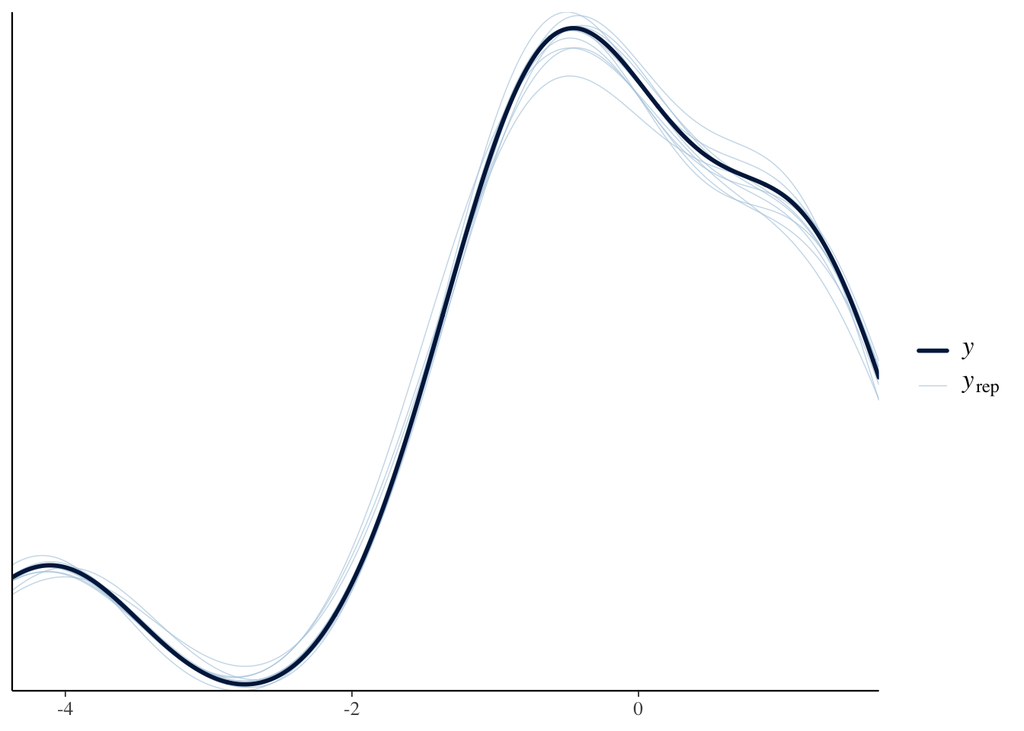

```r
pp_check(model_phylo_heart)
```

**Model summary**

```r
summary(model_phylo_heart)
```

```
 Family: gaussian
  Links: mu = identity
Formula: log10_organ_size ~ 1 + log10_body_size + (1 + log10_body_size | sex) + (1 | gr(phylo, cov = A_organ))
   Data: dat_organ (Number of observations: 20)
  Draws: 4 chains, each with iter = 4000; warmup = 2000; thin = 1;
         total post-warmup draws = 8000

Multilevel Hyperparameters:
~phylo (Number of levels: 10)
              Estimate Est.Error l-95% CI u-95% CI Rhat Bulk_ESS Tail_ESS
sd(Intercept)     0.53      0.16     0.31     0.91 1.00     1853     3477

~sex (Number of levels: 2)
                               Estimate Est.Error l-95% CI u-95% CI Rhat
sd(Intercept)                      0.20      0.25     0.00     0.92 1.00
sd(log10_body_size)                0.13      0.18     0.00     0.65 1.00
cor(Intercept,log10_body_size)    -0.05      0.63    -0.98     0.97 1.00
                               Bulk_ESS Tail_ESS
sd(Intercept)                      3157     4410
sd(log10_body_size)                2478     4175
cor(Intercept,log10_body_size)     5539     5172

Regression Coefficients:
                Estimate Est.Error l-95% CI u-95% CI Rhat Bulk_ESS Tail_ESS
Intercept          -2.63      0.39    -3.40    -1.84 1.00     2924     3641
log10_body_size     0.94      0.14     0.63     1.20 1.00     2455     2954

Further Distributional Parameters:
      Estimate Est.Error l-95% CI u-95% CI Rhat Bulk_ESS Tail_ESS
sigma     0.05      0.02     0.03     0.10 1.00     1641     2427

Draws were sampled using sample(hmc). For each parameter, Bulk_ESS
and Tail_ESS are effective sample size measures, and Rhat is the potential
scale reduction factor on split chains (at convergence, Rhat = 1).
```

**Phylogenetic signal**

```r
hyp <- paste(
  "sd_phylo__Intercept^2 /",
  "(sd_phylo__Intercept^2 + sd_sex__Intercept^2 + sigma^2) = 0"
)
(hyp <- hypothesis(model_phylo_heart, hyp, class = NULL))
```

```
Hypothesis Tests for class :
                Hypothesis Estimate Est.Error CI.Lower CI.Upper Evid.Ratio
1 (sd_phylo__Interc... = 0     0.84      0.22     0.21        1          0
  Post.Prob Star
1         0    *
---
'CI': 90%-CI for one-sided and 95%-CI for two-sided hypotheses.
'*': For one-sided hypotheses, the posterior probability exceeds 95%;
for two-sided hypotheses, the value tested against lies outside the 95%-CI.
Posterior probabilities of point hypotheses assume equal prior probabilities.
```

```r
lambda_heart <- hyp$hypothesis$Estimate
```

**Coefficients by sex**

```r
# Extract combined coefficients (fixed + random)
coef(model_phylo_heart)$sex %>%
{tibble(
  sex = dimnames(.)[[1]],
  intercept    = .[, "Estimate", "Intercept"],
  intercept_low  = .[, "Q2.5", "Intercept"],
  intercept_high = .[, "Q97.5", "Intercept"]
)} %>%
bind_cols(
  tibble(
    sex = dimnames(coef(model_phylo_heart)$sex)[[1]],
    slope = coef(model_phylo_heart)$sex[, "Estimate", "log10_body_size"]
  ) %>% select(slope),
  tibble(
    sex = dimnames(coef(model_phylo_heart)$sex)[[1]],
    slope_low  = coef(model_phylo_heart)$sex[, "Q2.5", "log10_body_size"],
    slope_high = coef(model_phylo_heart)$sex[, "Q97.5", "log10_body_size"]
  ) %>% select(slope_low, slope_high)
)
```

```
# A tibble: 2 × 7
  sex    intercept intercept_low intercept_high slope slope_low slope_high
  <chr>      <dbl>         <dbl>          <dbl> <dbl>     <dbl>      <dbl>
1 female     -2.64         -3.29          -1.94 0.948     0.764       1.12
2 male       -2.63         -3.28          -1.94 0.954     0.784       1.11
```

### Model comparison

```r
loo_simple <- loo(model_simple_heart)
loo_phylo <- loo(model_phylo_heart)
loo_compare(loo_simple, loo_phylo)
```

```
                   elpd_diff se_diff
model_phylo_heart    0.0       0.0
model_simple_heart -25.4       3.5
```

In this comparison, the model that accounts for phylogeny is clearly preferable to the model that treats species as independent observational units. The phylogenetic model (`model_phylo_heart`) is used as the reference with `elpd_diff = 0`, whereas the simpler model (`model_simple_heart`) has an expected log predictive density (ELPD) that is about 25.4 units lower, with an associated standard error of 3.5. In the context of leave‑one‑out cross‑validation, differences exceeding roughly four times their standard error are typically regarded as strong evidence. Here, 25.4/3.5≈7.3, indicating a very large difference relative to its uncertainty, and thus providing strong support for the phylogenetic model.

## Pituitary glands

### Filter data and prune tree

```r
# Filter organ of interest
dat_organ <- dat_mean %>%
  group_by(organ_grouped, sex) %>%
  ungroup() %>%
  filter(organ_grouped == "pituitary glands")

# Check for database/tree species mismatches
setdiff(tree$tip.label, dat_organ$phylo)      # Tree species absent in database
```

```
  [1] "Petrochromis_famula"             "Lobochilotes_labiatus"
  [3] "Simochromis_diagramma"           "Petrochromis_orthognathus"
  [5] "Ctenochromis_horei"              "Limnotilapia_dardennii"
  [7] "Gnathochromis_pfefferi"          "Tropheus_moorii"
  [9] "Tropheus_brichardi"              "Haplotaxodon_microlepis"
 [11] "Perissodus_microlepis"           "Benthochromis_tricoti"
 [13] "Cyprichromis_leptosoma"          "Greenwoodochromis_christyi"
 [15] "Limnochromis_staneri"            "Gnathochromis_permaxillaris"
 [17] "Baileychromis_centropomoides"    "Triglachromis_otostigma"
 [19] "Cyphotilapia_frontosa"           "Ophthalmotilapia_ventralis"
 [21] "Cyathopharynx_furcifer"          "Ophthalmotilapia_nasuta"
 [23] "Ophthalmotilapia_boops"          "Aulonocranus_dewindti"
 [25] "Ectodus_descampsii"              "Callochromis_melanostigma"
 [27] "Xenotilapia_melanogenys"         "Xenotilapia_flavipinnis"
 [29] "Eretmodus_cyanostictus"          "Tanganicodus_irsacae"
```

[output cut: 85 more lines]

```r
setdiff(dat_organ$phylo, tree$tip.label)      # Database species absent in tree
```

```
character(0)
```

```r
# Exclude mismatched species for consistency
tree_organ <- keep.tip(tree, intersect(tree$tip.label, dat_organ$phylo))
dat_organ <- dat_organ[dat_organ$phylo %in% tree_organ$tip.label, ]

# Re-check for mismatches after pruning
setdiff(tree_organ$tip.label, dat_organ$phylo)
```

```
character(0)
```

```r
setdiff(dat_organ$phylo, tree_organ$tip.label)
```

```
character(0)
```

```r
# Is ultrametric?
is.ultrametric(tree_organ)
```

```
[1] TRUE
```

```r
# how many species?
length(tree_organ$tip.label)
```

```
[1] 5
```

```r
# Compute phylogenetic covariance matrix
A_organ <- ape::vcv.phylo(tree_organ, corr = TRUE)
```

### Model simple

```r
model_simple_pituitary_glands <- brm(
  log10_organ_size ~
    1 +
    log10_body_size +
    (1 + log10_body_size | sex),
  data = dat_organ,
  family = gaussian(),
    prior = c(
    prior(normal(0.75, 0.5), class = "b", coef = "log10_body_size"),
    prior(normal(0, 2), class = "Intercept"),
    prior(student_t(3, 0, 0.5), class = "sd"),
    prior(student_t(3, 0, 1),   class = "sigma")
  ),
  seed = 6955,
  sample_prior = TRUE,
  chains = 4,
  cores = 4,
  threads = threading(2),
  iter = 4000,
  warmup = 2000,
  control = list(max_treedepth = 15,
                 adapt_delta = 0.99),
  save_pars = save_pars(all = TRUE),
  silent = TRUE, refresh = 0
)
```

```
Running MCMC with 4 parallel chains, with 2 thread(s) per chain...

Chain 3 finished in 4.0 seconds.
Chain 4 finished in 4.0 seconds.
Chain 2 finished in 4.6 seconds.
Chain 1 finished in 4.8 seconds.

All 4 chains finished successfully.
Mean chain execution time: 4.4 seconds.
Total execution time: 5.0 seconds.
```

**Model check**

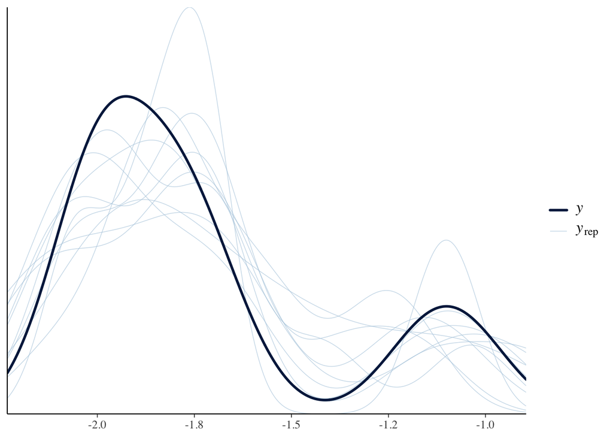

```r
pp_check(model_simple_pituitary_glands)
```

**Model summary**

```r
summary(model_simple_pituitary_glands)
```

```
 Family: gaussian
  Links: mu = identity
Formula: log10_organ_size ~ 1 + log10_body_size + (1 + log10_body_size | sex)
   Data: dat_organ (Number of observations: 10)
  Draws: 4 chains, each with iter = 4000; warmup = 2000; thin = 1;
         total post-warmup draws = 8000

Multilevel Hyperparameters:
~sex (Number of levels: 2)
                               Estimate Est.Error l-95% CI u-95% CI Rhat
sd(Intercept)                      0.31      0.32     0.01     1.19 1.00
sd(log10_body_size)                0.18      0.20     0.00     0.75 1.00
cor(Intercept,log10_body_size)    -0.07      0.60    -0.97     0.95 1.00
                               Bulk_ESS Tail_ESS
sd(Intercept)                      4018     3598
sd(log10_body_size)                1788     3113
cor(Intercept,log10_body_size)     4215     4178

Regression Coefficients:
                Estimate Est.Error l-95% CI u-95% CI Rhat Bulk_ESS Tail_ESS
Intercept          -3.74      0.34    -4.36    -2.98 1.00     4347     4113
log10_body_size     0.75      0.16     0.46     1.12 1.00     2277     1588

Further Distributional Parameters:
      Estimate Est.Error l-95% CI u-95% CI Rhat Bulk_ESS Tail_ESS
sigma     0.10      0.03     0.05     0.18 1.00     4141     4111

Draws were sampled using sample(hmc). For each parameter, Bulk_ESS
and Tail_ESS are effective sample size measures, and Rhat is the potential
scale reduction factor on split chains (at convergence, Rhat = 1).
```

**Coeficients by sex**

```r
# Extract combined coefficients (fixed + random)
coef(model_simple_pituitary_glands)$sex %>%
{tibble(
  sex = dimnames(.)[[1]],
  intercept    = .[, "Estimate", "Intercept"],
  intercept_low  = .[, "Q2.5", "Intercept"],
  intercept_high = .[, "Q97.5", "Intercept"]
)} %>%
bind_cols(
  tibble(
    sex = dimnames(coef(model_simple_pituitary_glands)$sex)[[1]],
    slope = coef(model_simple_pituitary_glands)$sex[, "Estimate", "log10_body_size"]
  ) %>% select(slope),
  tibble(
    sex = dimnames(coef(model_simple_pituitary_glands)$sex)[[1]],
    slope_low  = coef(model_simple_pituitary_glands)$sex[, "Q2.5", "log10_body_size"],
    slope_high = coef(model_simple_pituitary_glands)$sex[, "Q97.5", "log10_body_size"]
  ) %>% select(slope_low, slope_high)
)
```

```
# A tibble: 2 × 7
  sex    intercept intercept_low intercept_high slope slope_low slope_high
  <chr>      <dbl>         <dbl>          <dbl> <dbl>     <dbl>      <dbl>
1 female     -3.75         -4.20          -3.31 0.731     0.571      0.892
2 male       -3.79         -4.21          -3.36 0.714     0.567      0.860
```

### Model with phylogeny

```r
model_phylo_pituitary_glands <- brm(
  log10_organ_size ~
    1 +
    log10_body_size +
    (1 + log10_body_size | sex) +
    (1 | gr(phylo, cov = A_organ)),
  data = dat_organ,
  data2 = list(A_organ = A_organ),
  family = gaussian(),
    prior = c(
    prior(normal(0.75, 0.5), class = "b", coef = "log10_body_size"),
    prior(normal(0, 2), class = "Intercept"),
    prior(student_t(3, 0, 0.5), class = "sd"),
    prior(student_t(3, 0, 1),   class = "sigma")
  ),
  seed = 6955,
  sample_prior = TRUE,
  chains = 4,
  cores = 4,
  threads = threading(2),
  iter = 4000,
  warmup = 2000,
  control = list(max_treedepth = 15,
                 adapt_delta = 0.99),
  save_pars = save_pars(all = TRUE),
  silent = TRUE, refresh = 0
)
```

```
Running MCMC with 4 parallel chains, with 2 thread(s) per chain...

Chain 2 finished in 32.9 seconds.
Chain 4 finished in 43.3 seconds.
Chain 1 finished in 53.7 seconds.
Chain 3 finished in 96.0 seconds.

All 4 chains finished successfully.
Mean chain execution time: 56.5 seconds.
Total execution time: 96.1 seconds.
```

**Model check**

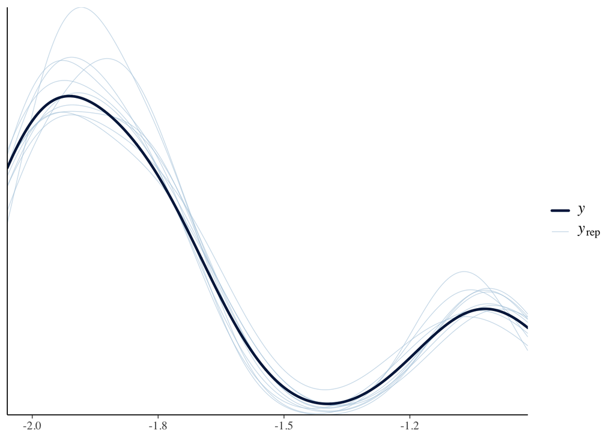

```r
pp_check(model_phylo_pituitary_glands)
```

**Model summary**

```r
summary(model_phylo_pituitary_glands)
```

```
 Family: gaussian
  Links: mu = identity
Formula: log10_organ_size ~ 1 + log10_body_size + (1 + log10_body_size | sex) + (1 | gr(phylo, cov = A_organ))
   Data: dat_organ (Number of observations: 10)
  Draws: 4 chains, each with iter = 4000; warmup = 2000; thin = 1;
         total post-warmup draws = 8000

Multilevel Hyperparameters:
~phylo (Number of levels: 5)
              Estimate Est.Error l-95% CI u-95% CI Rhat Bulk_ESS Tail_ESS
sd(Intercept)     0.16      0.10     0.05     0.40 1.00     2063     2185

~sex (Number of levels: 2)
                               Estimate Est.Error l-95% CI u-95% CI Rhat
sd(Intercept)                      0.24      0.29     0.01     1.04 1.00
sd(log10_body_size)                0.18      0.20     0.00     0.73 1.00
cor(Intercept,log10_body_size)    -0.05      0.61    -0.98     0.96 1.00
                               Bulk_ESS Tail_ESS
sd(Intercept)                      4165     4489
sd(log10_body_size)                2562     3028
cor(Intercept,log10_body_size)     5442     4775

Regression Coefficients:
                Estimate Est.Error l-95% CI u-95% CI Rhat Bulk_ESS Tail_ESS
Intercept          -3.83      0.45    -4.70    -2.92 1.00     2667     3522
log10_body_size     0.78      0.18     0.46     1.19 1.00     2415     2626

Further Distributional Parameters:
      Estimate Est.Error l-95% CI u-95% CI Rhat Bulk_ESS Tail_ESS
sigma     0.03      0.02     0.01     0.07 1.00      768     1777

Draws were sampled using sample(hmc). For each parameter, Bulk_ESS
and Tail_ESS are effective sample size measures, and Rhat is the potential
scale reduction factor on split chains (at convergence, Rhat = 1).
```

**Phylogenetic signal**

```r
hyp <- paste(
  "sd_phylo__Intercept^2 /",
  "(sd_phylo__Intercept^2 + sd_sex__Intercept^2 + sigma^2) = 0"
)
(hyp <- hypothesis(model_phylo_pituitary_glands, hyp, class = NULL))
```

```
Hypothesis Tests for class :
                Hypothesis Estimate Est.Error CI.Lower CI.Upper Evid.Ratio
1 (sd_phylo__Interc... = 0     0.49      0.35     0.01     0.99       0.32
  Post.Prob Star
1      0.24    *
---
'CI': 90%-CI for one-sided and 95%-CI for two-sided hypotheses.
'*': For one-sided hypotheses, the posterior probability exceeds 95%;
for two-sided hypotheses, the value tested against lies outside the 95%-CI.
Posterior probabilities of point hypotheses assume equal prior probabilities.
```

```r
lambda_pituitary_glands <- hyp$hypothesis$Estimate
```

**Coeficients by sex**

```r
# Extract combined coefficients (fixed + random)
coef(model_phylo_pituitary_glands)$sex %>%
{tibble(
  sex = dimnames(.)[[1]],
  intercept    = .[, "Estimate", "Intercept"],
  intercept_low  = .[, "Q2.5", "Intercept"],
  intercept_high = .[, "Q97.5", "Intercept"]
)} %>%
bind_cols(
  tibble(
    sex = dimnames(coef(model_phylo_pituitary_glands)$sex)[[1]],
    slope = coef(model_phylo_pituitary_glands)$sex[, "Estimate", "log10_body_size"]
  ) %>% select(slope),
  tibble(
    sex = dimnames(coef(model_phylo_pituitary_glands)$sex)[[1]],
    slope_low  = coef(model_phylo_pituitary_glands)$sex[, "Q2.5", "log10_body_size"],
    slope_high = coef(model_phylo_pituitary_glands)$sex[, "Q97.5", "log10_body_size"]
  ) %>% select(slope_low, slope_high)
)
```

```
# A tibble: 2 × 7
  sex    intercept intercept_low intercept_high slope slope_low slope_high
  <chr>      <dbl>         <dbl>          <dbl> <dbl>     <dbl>      <dbl>
1 female     -3.85         -4.64          -3.11 0.775     0.524      1.04
2 male       -3.85         -4.56          -3.15 0.745     0.517      0.973
```

### Model comparison

```r
loo_simple <- loo(model_simple_pituitary_glands)
loo_phylo <- loo(model_phylo_pituitary_glands)
loo_compare(loo_simple, loo_phylo)
```

```
                              elpd_diff se_diff
model_phylo_pituitary_glands    0.0       0.0
model_simple_pituitary_glands -11.8       1.6
```

In this comparison, the phylogenetic model is clearly preferable to the model treating species as independent observational units. The phylogenetic model (`model_phylo_pituitary_glands`) serves as reference with `elpd_diff = 0`, while the simpler model (`model_simple_pituitary_glands`) has an expected log predictive density (ELPD) that is about 11.8 units lower, with an associated standard error of 1.6. In leave-one-out cross-validation, differences exceeding approximately four times their standard error indicate strong evidence. Here, 11.8/1.6≈7.4, indicating a large difference relative to its uncertainty, and thus providing evidence favouring the phylogenetic model.

## Spleen

### Filter data and prune tree

```r
# Filter organ of interest
dat_organ <- dat_mean %>%
  group_by(organ_grouped, sex) %>%
  ungroup() %>%
  filter(organ_grouped == "spleen")

# Check for database/tree species mismatches
setdiff(tree$tip.label, dat_organ$phylo)      # Tree species absent in database
```

```
  [1] "Petrochromis_famula"             "Lobochilotes_labiatus"
  [3] "Simochromis_diagramma"           "Petrochromis_orthognathus"
  [5] "Ctenochromis_horei"              "Limnotilapia_dardennii"
  [7] "Gnathochromis_pfefferi"          "Tropheus_moorii"
  [9] "Tropheus_brichardi"              "Haplotaxodon_microlepis"
 [11] "Perissodus_microlepis"           "Benthochromis_tricoti"
 [13] "Cyprichromis_leptosoma"          "Greenwoodochromis_christyi"
 [15] "Limnochromis_staneri"            "Gnathochromis_permaxillaris"
 [17] "Baileychromis_centropomoides"    "Triglachromis_otostigma"
 [19] "Cyphotilapia_frontosa"           "Ophthalmotilapia_ventralis"
 [21] "Cyathopharynx_furcifer"          "Ophthalmotilapia_nasuta"
 [23] "Ophthalmotilapia_boops"          "Aulonocranus_dewindti"
 [25] "Ectodus_descampsii"              "Callochromis_melanostigma"
 [27] "Xenotilapia_melanogenys"         "Xenotilapia_flavipinnis"
 [29] "Eretmodus_cyanostictus"          "Tanganicodus_irsacae"
```

[output cut: 83 more lines]

```r
setdiff(dat_organ$phylo, tree$tip.label)      # Database species absent in tree
```

```
character(0)
```

```r
# Exclude mismatched species for consistency
tree_organ <- keep.tip(tree, intersect(tree$tip.label, dat_organ$phylo))
dat_organ <- dat_organ[dat_organ$phylo %in% tree_organ$tip.label, ]

# Re-check for mismatches after pruning
setdiff(tree_organ$tip.label, dat_organ$phylo)
```

```
character(0)
```

```r
setdiff(dat_organ$phylo, tree_organ$tip.label)
```

```
character(0)
```

```r
# Is ultrametric?
is.ultrametric(tree_organ)
```

```
[1] TRUE
```

```r
# how many species?
length(tree_organ$tip.label)
```

```
[1] 9
```

```r
# Compute phylogenetic covariance matrix
A_organ <- ape::vcv.phylo(tree_organ, corr = TRUE)
```

### Model simple

```r
model_simple_spleen <- brm(
  log10_organ_size ~
    1 +
    log10_body_size +
    (1 + log10_body_size | sex),
  data = dat_organ,
  family = gaussian(),
    prior = c(
    prior(normal(0.75, 0.5), class = "b", coef = "log10_body_size"),
    prior(normal(0, 2), class = "Intercept"),
    prior(student_t(3, 0, 0.5), class = "sd"),
    prior(student_t(3, 0, 1),   class = "sigma")
  ),
  seed = 6955,
  sample_prior = TRUE,
  chains = 4,
  cores = 4,
  threads = threading(2),
  iter = 4000,
  warmup = 2000,
  control = list(max_treedepth = 15,
                 adapt_delta = 0.99),
  save_pars = save_pars(all = TRUE),
  silent = TRUE, refresh = 0
)
```

```
Running MCMC with 4 parallel chains, with 2 thread(s) per chain...

Chain 1 finished in 1.4 seconds.
Chain 2 finished in 2.0 seconds.
Chain 4 finished in 2.0 seconds.
Chain 3 finished in 2.4 seconds.

All 4 chains finished successfully.
Mean chain execution time: 2.0 seconds.
Total execution time: 2.5 seconds.
```

**Model check**

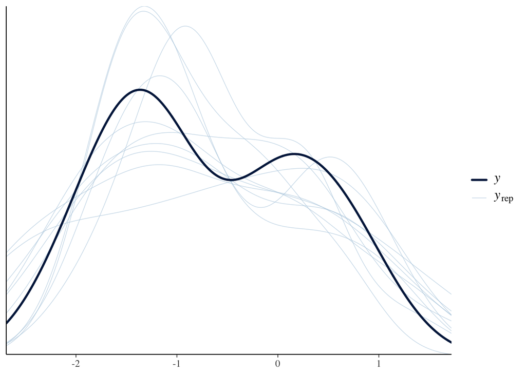

```r
pp_check(model_simple_spleen)
```

**Model summary**

```r
summary(model_simple_spleen)
```

```
 Family: gaussian
  Links: mu = identity
Formula: log10_organ_size ~ 1 + log10_body_size + (1 + log10_body_size | sex)
   Data: dat_organ (Number of observations: 18)
  Draws: 4 chains, each with iter = 4000; warmup = 2000; thin = 1;
         total post-warmup draws = 8000

Multilevel Hyperparameters:
~sex (Number of levels: 2)
                               Estimate Est.Error l-95% CI u-95% CI Rhat
sd(Intercept)                      0.32      0.32     0.01     1.14 1.00
sd(log10_body_size)                0.20      0.22     0.00     0.82 1.00
cor(Intercept,log10_body_size)    -0.10      0.59    -0.97     0.94 1.00
                               Bulk_ESS Tail_ESS
sd(Intercept)                      3318     3175
sd(log10_body_size)                2302     3173
cor(Intercept,log10_body_size)     4118     4275

Regression Coefficients:
                Estimate Est.Error l-95% CI u-95% CI Rhat Bulk_ESS Tail_ESS
Intercept          -3.01      0.39    -3.77    -2.18 1.00     4839     4271
log10_body_size     0.99      0.18     0.60     1.34 1.00     2407     1968

Further Distributional Parameters:
      Estimate Est.Error l-95% CI u-95% CI Rhat Bulk_ESS Tail_ESS
sigma     0.38      0.08     0.27     0.56 1.00     5903     4940

Draws were sampled using sample(hmc). For each parameter, Bulk_ESS
and Tail_ESS are effective sample size measures, and Rhat is the potential
scale reduction factor on split chains (at convergence, Rhat = 1).
```

**Coeficients by sex**

```r
# Extract combined coefficients (fixed + random)
coef(model_simple_spleen)$sex %>%
{tibble(
  sex = dimnames(.)[[1]],
  intercept    = .[, "Estimate", "Intercept"],
  intercept_low  = .[, "Q2.5", "Intercept"],
  intercept_high = .[, "Q97.5", "Intercept"]
)} %>%
bind_cols(
  tibble(
    sex = dimnames(coef(model_simple_spleen)$sex)[[1]],
    slope = coef(model_simple_spleen)$sex[, "Estimate", "log10_body_size"]
  ) %>% select(slope),
  tibble(
    sex = dimnames(coef(model_simple_spleen)$sex)[[1]],
    slope_low  = coef(model_simple_spleen)$sex[, "Q2.5", "log10_body_size"],
    slope_high = coef(model_simple_spleen)$sex[, "Q97.5", "log10_body_size"]
  ) %>% select(slope_low, slope_high)
)
```

```
# A tibble: 2 × 7
  sex    intercept intercept_low intercept_high slope slope_low slope_high
  <chr>      <dbl>         <dbl>          <dbl> <dbl>     <dbl>      <dbl>
1 female     -3.01         -3.58          -2.43  1.01     0.771       1.24
2 male       -3.06         -3.63          -2.49  1.02     0.787       1.25
```